# Pulse of the Nation Chi-Square

```r
POTN<-read.csv("../Data/201709PotNs.csv", header=TRUE, stringsAsFactors = FALSE)
```

### Overview

[Pulse of the Nation](https://thepulseofthenation.com/#intro) is a government funded monthly public opinion poll. The organization “Fifth Day of Cards Against Humanity Saves America” conducted the poll . To conduct their polls in a scientifically rigorous manner, they partnered with Survey Sampling International — a professional research firm — to contact a nationally representative sample of the American public. They interrupted people’s dinners on both their cell phones and land-lines to examine the data for statistically significant correlations.

The [Dataset](https://thepulseofthenation.com/downloads/201709-CAH_PulseOfTheNation_Raw.csv) I will use is a subset of the results of the [survey for September 2017](https://thepulseofthenation.com/#poll-1).

### Dataset

For this analysis, I will explore this question:

**Is Political Affiliation independent of Marital Status?**

The levels for each category are:

**PA:** Political Affiliation

- Democrat
- Don’t Know
- Independent
- Republican

**MS:** Marital Status

- Divorced
- Relationship
- Married
- Separated
- Single
- Widowed

Here is the data I will be using:

```r
datatable(POTN, extensions = "Responsive",options=list(lengthMenu = c(10,25,68)))
```

|  | Gender | Age | PA | ED | race | MS |
| --- | --- | --- | --- | --- | --- | --- |
| 1 | Female | 64 | Democrat | College degree | White | Divorced |
| 2 | Female | 56 | Democrat | High school | Black | Single |
| 3 | Male | 63 | Independent | Some college | White | Married |
| 4 | Male | 48 | Republican | High school | White | Divorced |
| 5 | Female | 32 | Democrat | Some college | White | Married |
| 6 | Female | 64 | Democrat | Some college | White | Married |
| 7 | Male | 61 | Independent | College degree | White | Divorced |
| 8 | Female | 64 | Republican | College degree | White | Married |
| 9 | Female | 64 | Republican | High school | White | Married |
| 10 | Female | 68 | Democrat | Some college | White | Widowed |

[output cut: 981 more lines]

### Chi-Squared test of independence

To test to see if political affiliation is independent of marital status, I will test

$$H_0:\text{Political affiliation is independent of marital status.}$$
$$H_a:\text{Political affiliation is associated with marital status.}$$

#### Observed Counts

```r
table.pams<-table(POTN$MS,POTN$PA)
pander(table.pams)
```

|  | Democrat | DK/REF | Independent | Republican |
| --- | --- | --- | --- | --- |
| **Divorced** | 22 | 16 | 32 | 13 |
| **Married** | 130 | 60 | 188 | 133 |
| **Relationship** | 19 | 14 | 38 | 19 |
| **Separated** | 6 | 4 | 6 | 1 |
| **Single** | 74 | 44 | 73 | 23 |
| **Widowed** | 23 | 10 | 24 | 19 |

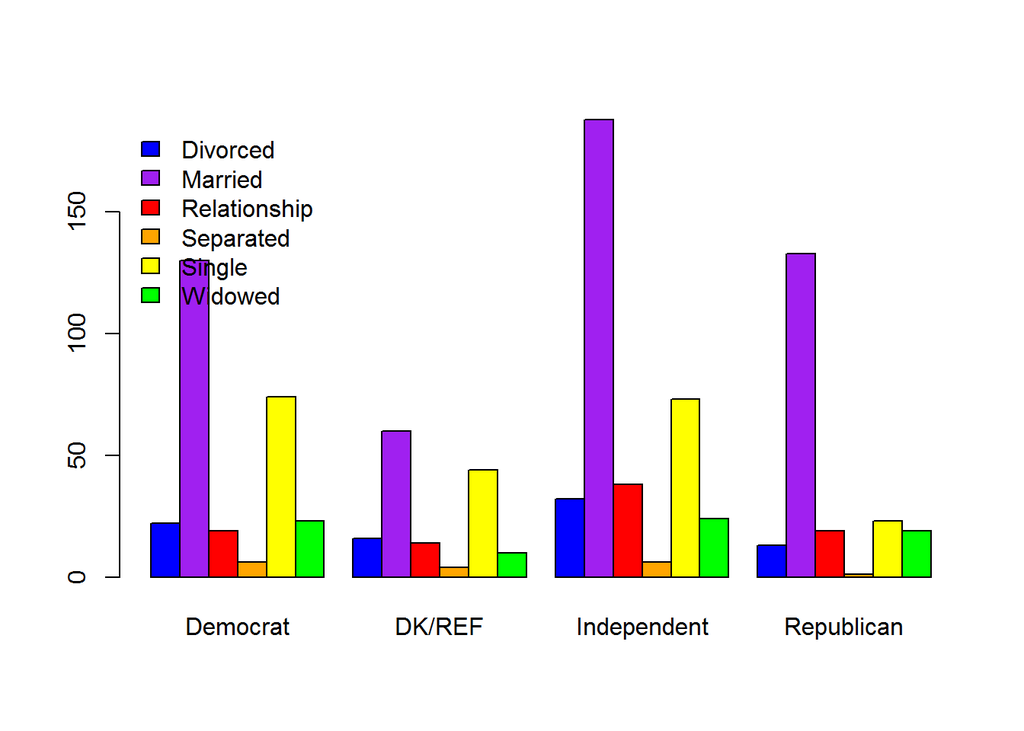

```r
barplot(table.pams,col=c("blue","purple","red","orange","yellow","green") ,beside=TRUE, legend.text=TRUE, args.legend=list(x = "topleft", bty="n"))
```

#### Chi-Squared Results

```r
chipotn <- chisq.test(table.pams)
pander(chipotn)
```

Pearson’s Chi-squared test: `table.pams`

| Test statistic | df | P value |
| --- | --- | --- |
| 38.88 | 15 | 0.0006669 * * * |

```r
cpv<-chisq.test(table.pams)$p.value
```

### Interpretation

#### Assumptions

1. Because of the nature of this data collection, we can assume that the data is randomly collected.
2. All of the expected counts are greater than 1.
3. Even though not all of the expected counts are greater than 5, the average of the counts is greater than 5.

#### Expected Counts

```r
pander(chipotn$expected)
```

|  | Democrat | DK/REF | Independent | Republican |
| --- | --- | --- | --- | --- |
| **Divorced** | 22.95 | 12.4 | 30.24 | 17.42 |
| **Married** | 141.3 | 76.31 | 186.1 | 107.3 |
| **Relationship** | 24.88 | 13.44 | 32.79 | 18.89 |
| **Separated** | 4.7 | 2.539 | 6.193 | 3.568 |
| **Single** | 59.17 | 31.96 | 77.96 | 44.92 |
| **Widowed** | 21.01 | 11.35 | 27.69 | 15.95 |

#### Conclusion

The Chi-squared test of independence between political affiliation and marital status yields a p-value of *0.0006669*. The test results seem significant.

1. Reject the null hypothesis.
2. Conclude that political affiliation is associated with marital status.

#### Residuals

```r
pander(chipotn$residuals)
```

|  | Democrat | DK/REF | Independent | Republican |
| --- | --- | --- | --- | --- |
| **Divorced** | -0.198 | 1.024 | 0.321 | -1.059 |
| **Married** | -0.9495 | -1.868 | 0.1359 | 2.486 |
| **Relationship** | -1.18 | 0.1525 | 0.9108 | 0.02531 |
| **Separated** | 0.5995 | 0.917 | -0.07745 | -1.36 |
| **Single** | 1.928 | 2.13 | -0.5613 | -3.27 |
| **Widowed** | 0.4334 | -0.4008 | -0.7004 | 0.7633 |

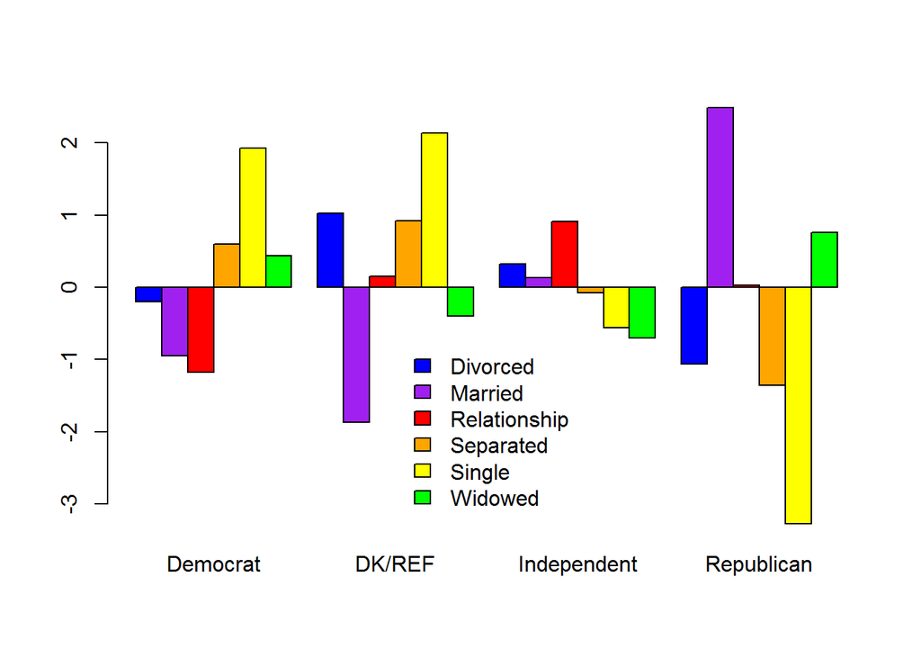

```r
barplot(chipotn$residuals,col=c("blue","purple","red","orange","yellow","green") , beside=TRUE, legend.text=TRUE, args.legend=list(x = "bottom", bty="n"))
```

#### Unexpected Results

1. Republicans have an unexpectedly low rate of singles.
2. Republicans have an unexpectedly high rate of marriage.
3. The unaffiliated have an unexpectedly low rate of marriage.
4. The unaffiliated have and unexpectedly high rate of singles.
5. The Democrats have and unexpectedly high rate of singles.